# Homework 6

## Problem #1: Testing coin flips (6 pts)

In the six sequences below, only one of them is actually **randomly generated from independent flips of a fair coin**. Use a combination of everything you know (common sense, Monte Carlo, hypothesis testing, etc.) to identify which is actually random and explain your reasoning.

(For full points, conduct a formal test and report a $p$-value for each sequence. You may use a combination of multiple tests to arrive at your answer. If you cannot compute a p-value for each sequence, you can still earn a significant amount of partial credit by carefully explaining your reasoning and response as best as you can.)

My advice is **be creative** with the test statistics you come up with to eliminate each sequence! Think of some way of summarizing a sequence of flips that might be useful for comparing against a simulated sequence of random flips. After you come up with an idea for a statistic, remember to run it on many MC generated completely random flips to produce a distribution under the null, which you can then compare with your data to get a p-value. Also, be careful of now you define “more extreme” than the data.

(2 bonus points available if you can find a single test that is powerful enough to reject all the fake sequences together in one step. Yes, at least one such possible test exists.)

```r
#this is a sequence of HT/TH pairs, sim from a Bernoulli N times to generate a coinflip sample and see how many HT pairs exist in that
#arbitrarily assign heads to 1 and tails to 0
tableOfPairs = function(vec){
  return(table(runner::runner(vec,k=2,f=paste,collapse="")[-1]))
}
split = function(str) strsplit(str, split="")[[1]]

flips1 = "HTHTHTHTHTHTHTHTHTHTHTHTHTHTHTHTHTHTHTHTHTHTHTHTHTHTHTHTHTHT…"
reps = replicate(1e3, unname(tableOfPairs(rbinom(length(split(flips1)), 1, .5))[ "10"]))
num_pairs = unname(tableOfPairs(split(flips1))["HT"])
mean(reps >= num_pairs)
```

```
## [1] 0
```

From our simulation we can see $p < \frac{1}{1000}$, of getting the same number of pairs from a fair distribution, so we reject the null and this coin is not fair.

Recall the properties of a Binomial, we already have a binary fixed number of trials, but we must test for:

Independence and success rate for each flip

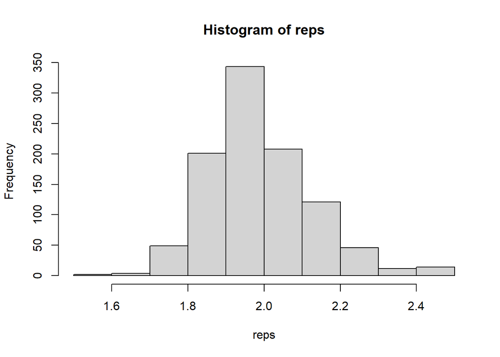

```r
#seems to have runs broken up frequently, investigate the average run length
ratioFromTable = function(tb){
  return(setNames((tb["HH"]/tb["HT"])/(tb["TT"]/tb["TH"]),"R"))
}
ratioFromTableBinom = function(tb){
  return(setNames((tb["11"]/tb["10"])/(tb["00"]/tb["01"]),"R"))
}
avgRunLength = function(x) {
  mean(rle(x)$lengths)
}

genFlip = function(n) {
  rbinom(n, 1, .5)
}

flips2 = "HHHTHTTTHHTHHTHHHTTTTHTHTHHTTHTHHHTHHTHTTTHTHHHTHTTTHTHTHHTH…"

reps = replicate(1e3, avgRunLength(rbinom(length(split(flips2)), 1, .5)))
hist(reps)
```

```r
#appears there are no observed average run lengths that match coin 2
runs = rle(split(flips2))$lengths

average_run_length = mean(runs)
mean(average_run_length >= reps)
```

```
## [1] 0
```

From our simulation we can see $p < \frac{1}{1000}$ of getting a smaller average run length from a fair coinflip, so we reject the null and this is not a fair coin.

```r
flips3 = "HHTHTHTTTHTHHHTHHTTTHTHHTHTTTHTHTHHTHTHTTHTHHHHHHTTTHTHTHHTH…"
flips3 = split(flips3)
runs = rle(flips3)$lengths
average_run_length = mean(runs)
average_run_length
```

```
## [1] 1.6
```

This appears to be on the leftmost tail of our distribution of avg. run length, use a one-tailed test.

```r
reps = replicate(1e3, avgRunLength(rbinom(length(flips3), 1, .5)))
mean(average_run_length >= reps)
```

```
## [1] 0
```

We reject the null that this sample is fair, there is statistically significant evidence ($p < .05$) flips are not independent.

```r
flips4 = "HTHHHHHHHTHTTHHTTHHHTHTHTTTHHTHHHTHHTTHTTTTTTTTTHTHHTTTTTHTH…"
flips4 = split(flips4)
reps = replicate(1e3, ratioFromTableBinom(tableOfPairs(genFlip(length(flips4)))))
test_stat = ratioFromTable(tableOfPairs(flips4))
test_stat
```

```
##         R
## 0.9387755
```

```r
mean(test_stat >= reps)
```

```
## [1] 0.419
```

```r
reps = replicate(1e3, avgRunLength(rbinom(length(flips4), 1, .5)))
runs = rle(flips4)$lengths
average_run_length = mean(runs)
average_run_length
```

```
## [1] 1.904762
```

```r
mean(average_run_length >= reps)
```

```
## [1] 0.257
```

```r
flips5 = "HHHHHHHHHHTTTTTTTTTTHHHHHHHHHHTTTTTTTTTTHHHHHHHHHHTTTTTTTTTT…"
flips5 = split(flips5)
reps = replicate(1e3, avgRunLength(rbinom(length(flips5), 1, .5)))
runs = rle(flips5)$lengths
average_run_length = mean(runs)
mean(average_run_length <= reps)
```

```
## [1] 0
```

There is statistcially significant evidence ($p < .05$) this is not drawn from a binomial distribution.

```r
flips6 = "TTHTTTHTTTTTTTHTHTHTHTTHTTHTHHTHHTTTHHTHTTTHTHHTHHHTHTTHHTHH…"
flips6 = split(flips6)
test_stat = ratioFromTable(tableOfPairs(flips6))
test_stat
```

```
##         R
## 0.2531646
```

Independent samples should be $\approx 1$, this is clearly on the left tail so we will do a one-sided test.

```r
reps = replicate(1e3, ratioFromTableBinom(tableOfPairs(genFlip(length(flips6)))))
mean(test_stat >= reps)
```

```
## [1] 0
```

Since there is statistically significant evidence this sample doesn’t have independent flips ($p < .05$) we conclude this is not a fair coin.

## Problem #2: Finding the Trick Coin (6 pts; 2pts each)

I have two coins in my pocket - a trick coin with two heads and a fair coin with one head and one tail(s?). We’ll play a game. I will grab one coin at random, and flip it $N$ times. After that you will have to decide if it is the fair coin or the trick coin. The null hypothesis is that it is the fair coin.

**Decision Rule 1**: If after $N$ flips there are no tails, then you decide it is the trick coin. If there is at least 1 tail then you know it is the fair coin.

1. Using “Decision Rule 1”, what is the lowest number of flips $N$ would you need in order to have a significance level less than 5% for this test?

$$.5^N = .05$$

$$N = \frac{log(.05)}{log(.5)} \approx
4.32$$

There will be a minimum of $5$ flips.

2. Using $N$ from part a, what is the power of the test?

To have a true positive we get $N = 5$ heads in a row. However, the only time $H_0$ is false is if we picked the trick coin, so there is a $1$ probability of getting $5$ heads in a row.

$$P(\text{reject } H_0 | H_0 \text{
false}) = 1$$

3. Suppose $N=4$ is decided. How can you modify the decision process to have a significance level of exactly 5%? Does this change the power of the test?

The significance level is given by $\alpha = P(\text{reject } H_0 | H_0 \text{ true})$

Using decision rule 1: $P(\text{reject } H_0 | H_0 \text{ true}) = .5^4 = \frac{1}{16}$

$$\frac{1}{16} \cdot \frac{4}{5} =
\frac{1}{20}$$

Revised decision rule: if after N flips there are no tails, roll a fair 5-sided die, if the die lands between 1-4, decide it’s the trick coin. Otherwise if it lands on 5, decide it’s the fair coin.

Using the new decision rule, $P(\text{reject } H_0 | H_0 \text{ false}) = 1 * \frac{4}{5} \neq 1$

4. Extra Credit (2 points): Suppose if you guess correct you win $100 (and if you’re wrong you get nothing), but each flip of the coin costs $10. What strategy would you use to maximize your expected profit from this game?

Expected profit per round can be modeled as $100 * P(\text{True Positive} | H_0 \text{ True}) - 10 * f$ or $100 * P(\text{True Negative} | H_0 \text{ False} - 10 * f)$ given that there is a 50-50 chance of $H_0$ being true or false:

$p = \frac{100 * P(\text{True Positive}) - 10 * f}{2} + \frac{100 * P(\text{True Negative}) - 10 * f}{2} = 50[P(\text{True Positive}) + P(\text{True Negative})] - 10f$

## Problem #3: Testing the maximum of a uniform distribution (8 pts; 2 pts each)

We sample $X_1, X_x,\ldots,X_n \overset{\text{iid}}\sim\text{Uniform}(0,m)$ where $m$ is an unknown maximum. Sleazy Jim tells you that $m=1$ but you’re not so sure. The 50 values sampled are in the following data file:

```r
X <- read.csv("./../../data/uniform_sample.csv")$x
X
```

```
##  [1] 0.343246125 0.845331763 0.684962514 0.169305117 0.200210369 0.356923825
##  [7] 0.618709566 0.356788725 0.463665448 0.140930417 0.371956468 0.290623483
## [13] 0.913263779 0.009077785 0.224780933 0.042212803 0.765213745 0.234971749
## [19] 0.110230761 0.356156177 0.753888071 0.245138641 0.377871093 0.591001945
## [25] 0.718874781 0.460685407 0.723332535 0.467167955 0.805576242 0.105145157
## [31] 0.332226258 0.282394464 0.367354850 0.591933796 0.548251072 0.014293113
## [37] 0.706164011 0.407966349 0.712363180 0.153611100 0.043375899 0.856637282
## [43] 0.565973643 0.944338254 0.099868015 0.810696513 0.497407495 0.023248688
## [49] 0.181430286 0.341202305
```

1. Write out in formal notation the null and alternative hypotheses.
   $$H_0: X_1, X_x,\ldots,X_n
   \overset{\text{iid}}\sim\text{Uniform}(0,1)$$
   $$H_A: X_1, X_x,\ldots,X_n \overset{\text{iid}}\sim
   \text{Uniform}(0,m), m < 1$$
2. Come up with a test statistic and measure your sampled data. Is this a one-sided test or two-sided test?

We will use the mean of the distribution as a test.

```r
mean(X)
```

```
## [1] 0.4245596
```

Since the mean is < 1 and there are no values in the distribution > 1 we will use a one-sided test on the left tail of the simulated distribution.

3. Simulate a distribution for the test statistic under the null hypothesis of size at least 1000. Display a histogram of your test statistic distribution.

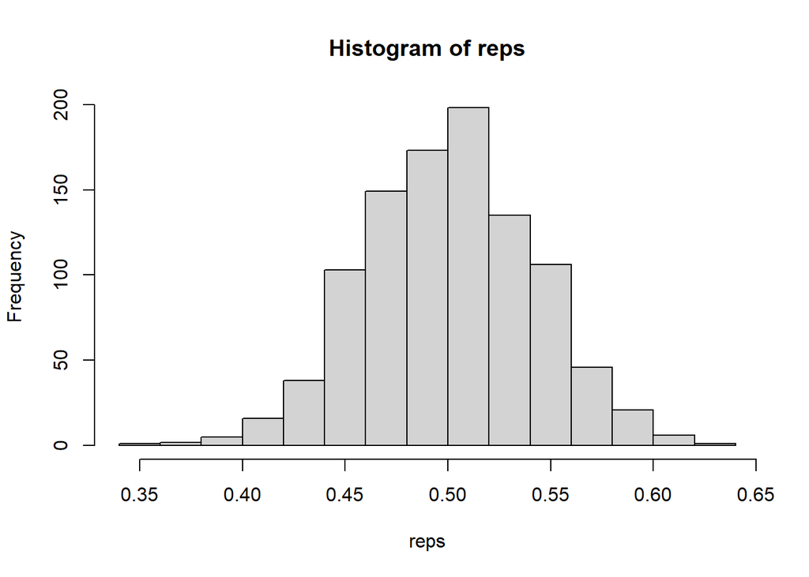

```r
reps = replicate(1e3, mean(runif(length(X), min=0, max=1)))
hist(reps)
```

4. Calculate the $p$-value for this data and make a conclusion.

```r
mean(mean(X) >= reps)
```

```
## [1] 0.033
```

Since we have $p < .05$ we reject the null hypothesis and conclude $H_A: X_1, X_x,\ldots,X_n \overset{\text{iid}}\sim \text{Uniform}(0,m), m<1$

## Problem #4: Blurtle (10 pts; 2 pt each)

Have you been playing the hot new game Blurtle? It’s a (fictional) word game you can play daily - you have to guess a 5 letter word and you only have 6 attempts. I’ve been playing for the past 100 days and I’ve been tracking my number of guesses. I’m trying to figure out whether I have been getting better or not.

The file `blurtle.csv` contains 100 rows of data, giving the number of tries to guess the word. If it took 7 guesses that actually means I failed (you don’t actually get a 7th guess).

```r
blurtle <- read.csv("./../../data/blurtle.csv")
```

Your task is to perform a permutation test on the data to determine if there is statistical evidence of a true improvement trend.

1. State the null and alternative hypotheses
   $$H_0: \text{The number of attempts on any given
   day is random}$$
   $$H_A: \text{The
   number of attempts follows a downward trend}$$
2. Determine a test statistic that identifies a trend in the number of tries. There are many good ones you could use - be creative.

Find the average sequential differences in each day. I.e.$X = \{x_1, x_i, \cdots, x_m\}$ use $\frac{\sum_{i = 2}^m x_i - x_{i - 1}}{m - 1}$

3. Decide whether the test will be a one or two-tailed test

The test will be one-tailed on the left tail since we want to see if a downward trend exists in the data.

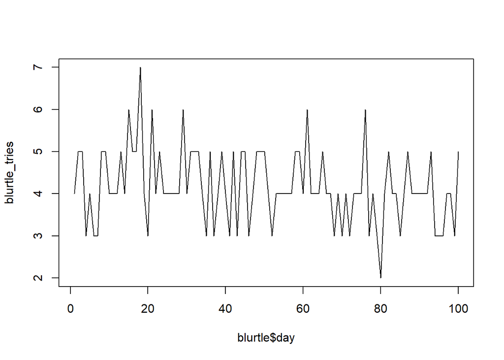

```r
blurtle_tries = unlist(blurtle$tries)
plot(blurtle$day, blurtle_tries, type = "l")
```

```r
avg_seq_diff = function(v) {
  total = 0
  for (i in 2:length(v)) {
    total = total + v[i] - v[i - 1]
  }
  total / (length(v) - 1)
}
```

4. Simulate a distribution of test statistics under the null hypothesis

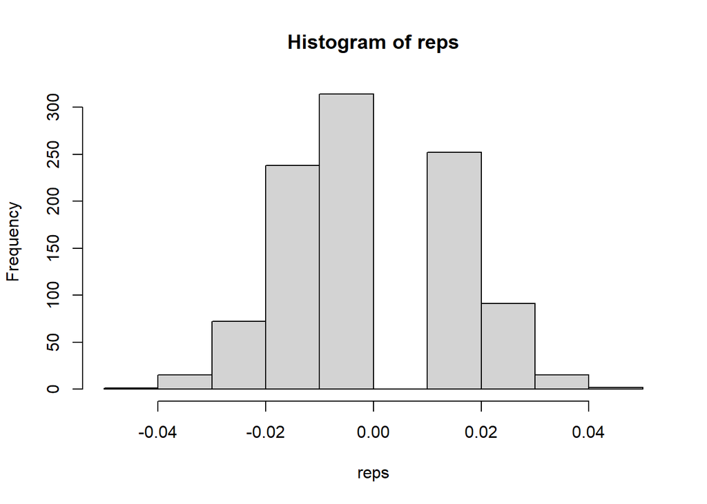

```r
reps = replicate(1e3, avg_seq_diff(sample(blurtle_tries)))
hist(reps)
```

5. Calculate the test statistic on the observed data, calculate the $p$-value and state your conclusions.

```r
mean(avg_seq_diff(blurtle_tries)>= reps)
```

```
## [1] 0.892
```